# Assignment 4 Q3

Barbara Rose Hoover

11/12/2018

### 3. Describe Lobster Abundance and Fishing Pressure (2012-2017)

#### At Isla Vista and Naples Reef, the two protected MPA sites (with zero fishing pressure), how do lobster sizes in 2012 and 2017 compare? At the non-MPA sites?

### Data.frame: All 5 sites in Frequency Format

- SITE
  - “AQUE” “CARP” “IVEE” “MOHK” “NAPL”
- YEAR
  - 2012, 2017
- MPA
  - Designated (Yes, No)

Table to include only head of table (out of 1074 observations)

| YEAR | SITE | SIZE | COUNT | MPA |
| --- | --- | --- | --- | --- |
| 2012 | IVEE | 70 | 1 | Yes |
| 2012 | IVEE | 60 | 1 | Yes |
| 2012 | IVEE | 65 | 1 | Yes |
| 2012 | IVEE | 70 | 1 | Yes |
| 2012 | IVEE | 85 | 1 | Yes |
| 2012 | IVEE | 60 | 1 | Yes |

### Data.frame: All 5 sites expanded from Frequency to Case Format (n=1,899)

| YEAR | SITE | SIZE | COUNT | MPA |
| --- | --- | --- | --- | --- |
| 2012 | IVEE | 70 | 1 | Yes |
| 2012 | IVEE | 60 | 1 | Yes |
| 2012 | IVEE | 65 | 1 | Yes |
| 2012 | IVEE | 70 | 1 | Yes |
| 2012 | IVEE | 85 | 1 | Yes |
| 2012 | IVEE | 60 | 1 | Yes |

### Box Plot

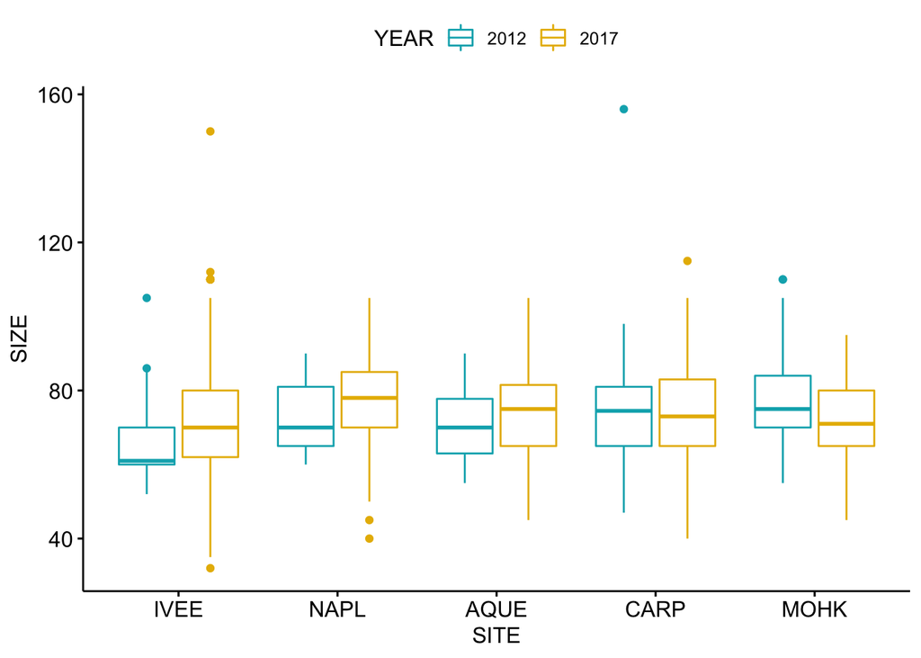

- All Sites
- Years 2012, 2017

## IVEE (MPA)

#### Visual Data

2012

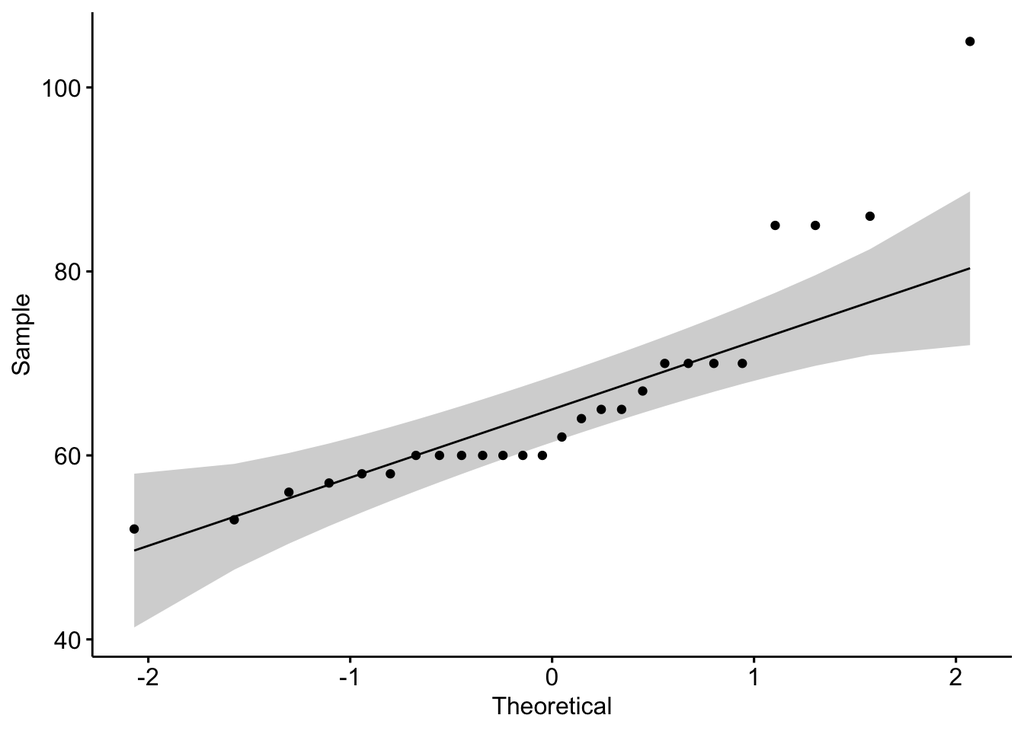

2017

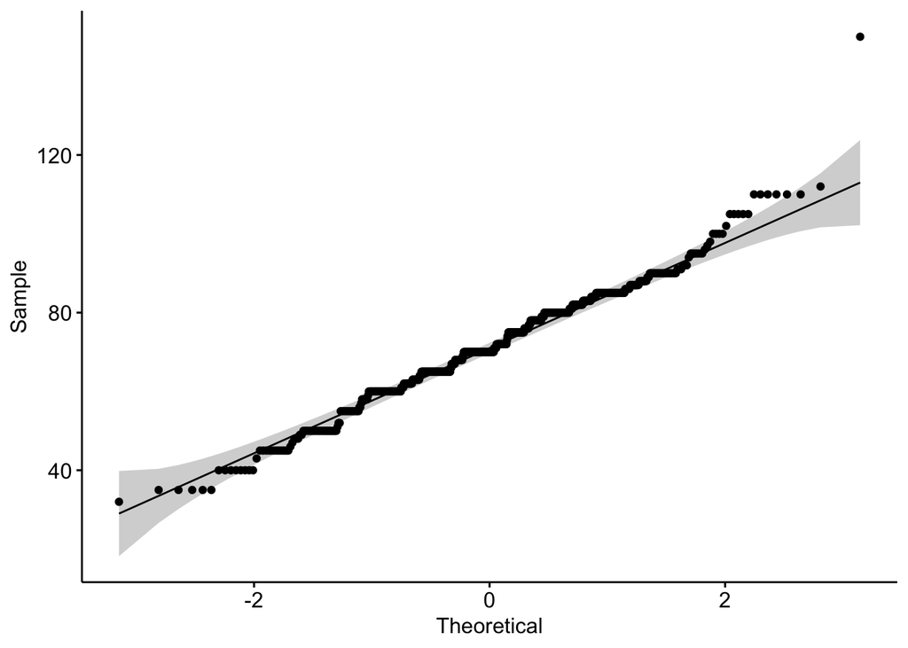

#### F test for variance

```
##
##  F test to compare two variances
##
## data:  ivee_2012_3$SIZE and ivee_2017_3$SIZE
## F = 0.71311, num df = 25, denom df = 605, p-value = 0.307
## alternative hypothesis: true ratio of variances is not equal to 1
## 95 percent confidence interval:
##  0.4322948 1.3698611
## sample estimates:
## ratio of variances
##           0.713111
```

RESULT:  
p-value for the variance test, (0.3069638) is larger than the significance level $\alpha$ = 0.05. There is not a significant difference between the variances of the two sets of data. We will need to use student’s t-test, which is designed for equal variances, and the assumption of normality.

#### Shapiro-Wilk normality test

```
##
##  Shapiro-Wilk normality test
##
## data:  ivee_2012_3$SIZE
## W = 0.81375, p-value = 0.0003044
```

p-value = 0.0003044

RESULT:  
From the output, the p-value (3.044364910^{-4}) < 0.05 implying that the distribution of the data are significantly different from normal distribution. In other words, we cannot assume the normality, and will have to use Welch’s t-test.

#### T-test

```
##
##  Welch Two Sample t-test
##
## data:  ivee_2012_3$SIZE and ivee_2017_3$SIZE
## t = -2.2013, df = 28.095, p-value = 0.0361
## alternative hypothesis: true difference in means is not equal to 0
## 95 percent confidence interval:
##  -10.3764247  -0.3740196
## sample estimates:
## mean of x mean of y
##  66.07692  71.45215
```

RESULT:  
Mean Lobster Sizes differ significantly between the 2012 and 2017 at IVEE at the 0.05 confidence level. (t(28.09) = -2.2, *p* = 0.0360973).

## NAPL (MPA)

##### Visual data

2012

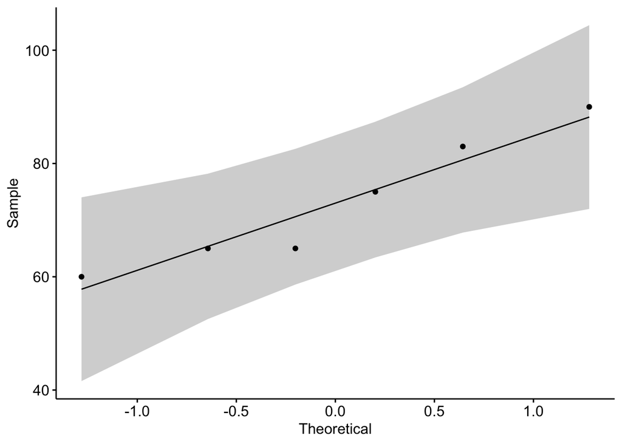

2017

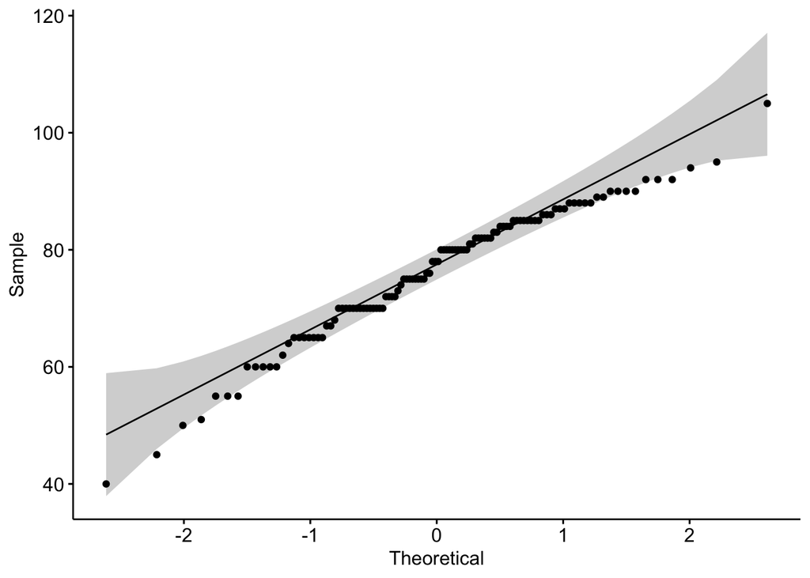

#### Shapiro-Wilk’s test for normality (n<30)

```
##
##  Shapiro-Wilk normality test
##
## data:  napl_2012_3$SIZE
## W = 0.92214, p-value = 0.5209
```

p-value = 0.5209

RESULT:  
From the output, the p-value (0.5208858) > 0.05 implying that the distribution of the data are not significantly different from normal distribution. In other words, we can assume the normality.

#### F test for variance

```
##
##  F test to compare two variances
##
## data:  napl_2012_3$SIZE and napl_2017_3$SIZE
## F = 1.064, num df = 5, denom df = 111, p-value = 0.7685
## alternative hypothesis: true ratio of variances is not equal to 1
## 95 percent confidence interval:
##  0.3966019 6.4626426
## sample estimates:
## ratio of variances
##           1.064048
```

RESULT:  
p-value for the variance test, (0.7685137) is larger than the significance level $\alpha$ = 0.05. There is not a significant difference between the variances of the two sets of data. We will need to use student’s t-test, which is designed for equal variances, and the assumption of normality.

#### T-test

```
##
##  Two Sample t-test
##
## data:  napl_2012_3$SIZE and napl_2017_3$SIZE
## t = -0.67636, df = 116, p-value = 0.5002
## alternative hypothesis: true difference in means is not equal to 0
## 95 percent confidence interval:
##  -12.697051   6.232765
## sample estimates:
## mean of x mean of y
##  73.00000  76.23214
```

RESULT:  
Mean Lobster Sizes do not differ significantly between the 2012 and 2017 at NAPL at the 0.05 confidence level. (t(116) = -0.68, *p* = 0.5001597).

## AQUE

2012

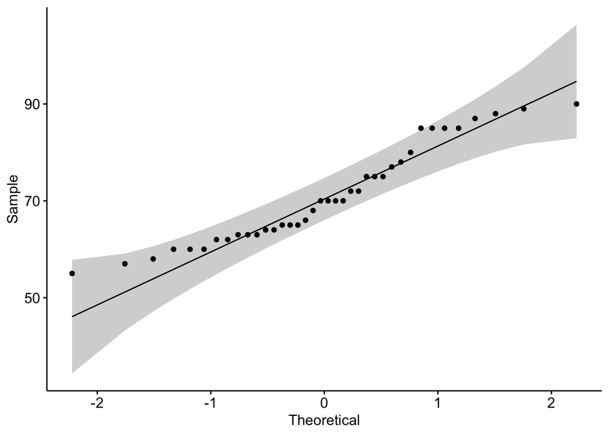

2017

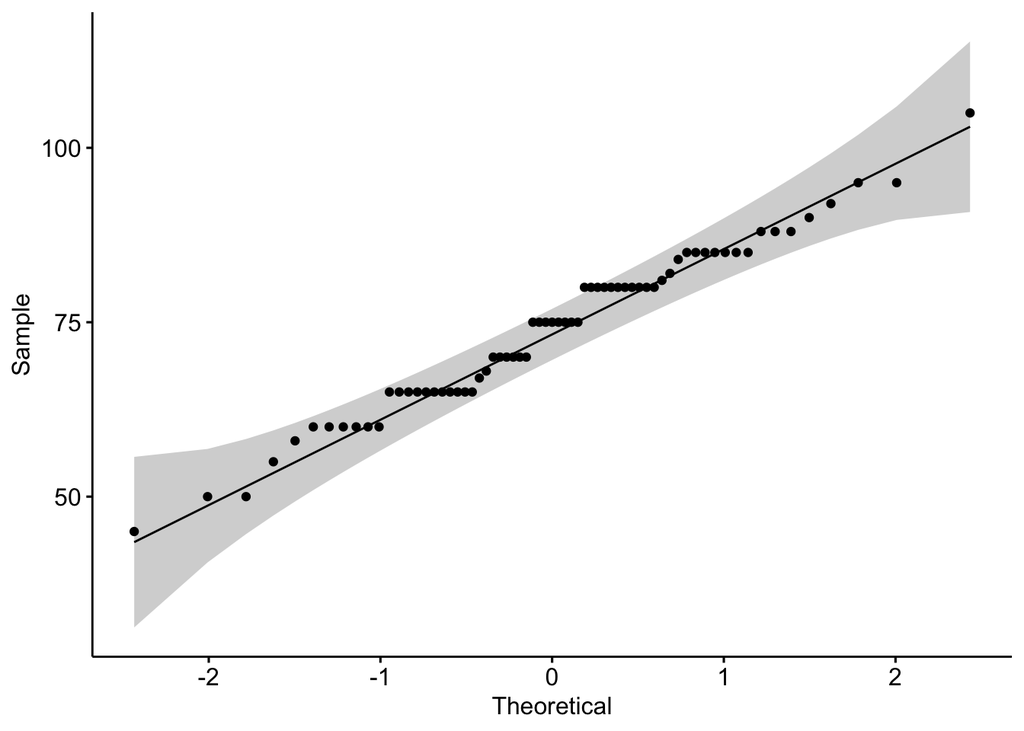

#### F test for variance

```
##
##  F test to compare two variances
##
## data:  aque_2012_3$SIZE and aque_2017_3$SIZE
## F = 0.72863, num df = 37, denom df = 66, p-value = 0.2986
## alternative hypothesis: true ratio of variances is not equal to 1
## 95 percent confidence interval:
##  0.419142 1.327868
## sample estimates:
## ratio of variances
##          0.7286314
```

RESULT:  
p-value for the variance test, (0.2986163) is larger than the significance level $\alpha$ = 0.05. There is not a significant difference between the variances of the two sets of data. We will need to use student’s t-test, which is designed for equal variances, and the assumption of normality.

#### T-test

```
##
##  Two Sample t-test
##
## data:  aque_2012_3$SIZE and aque_2017_3$SIZE
## t = -1.2622, df = 103, p-value = 0.2097
## alternative hypothesis: true difference in means is not equal to 0
## 95 percent confidence interval:
##  -7.445357  1.654312
## sample estimates:
## mean of x mean of y
##  71.00000  73.89552
```

RESULT:  
Mean Lobster Sizes do not differ significantly between the 2012 and 2017 at AQUE at significance level $\alpha$ = 0.05. (t(103) = -1.26, *p* = 0.2097443).

## MOHK

#### Visual Data

2012

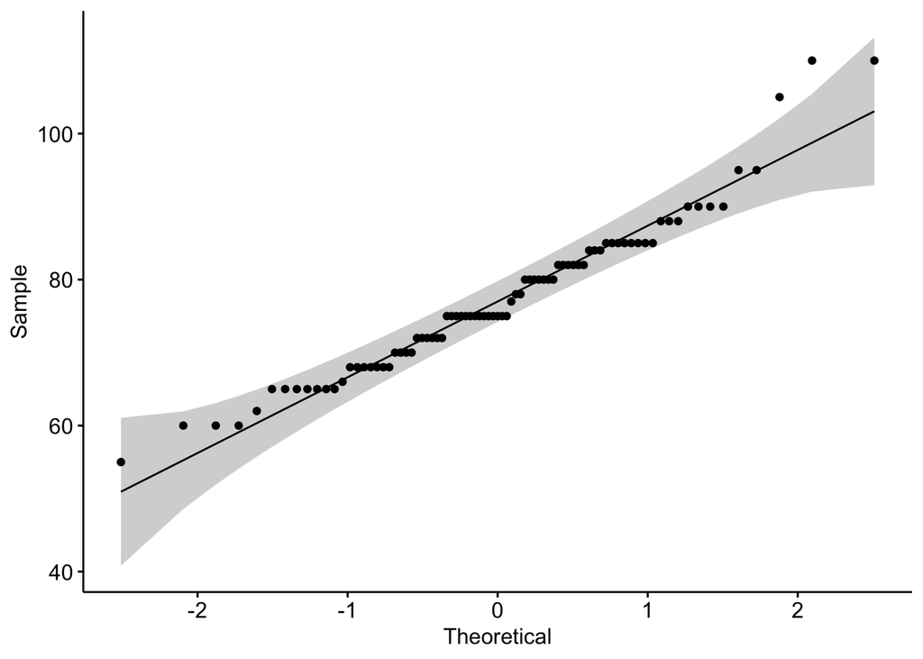

2017

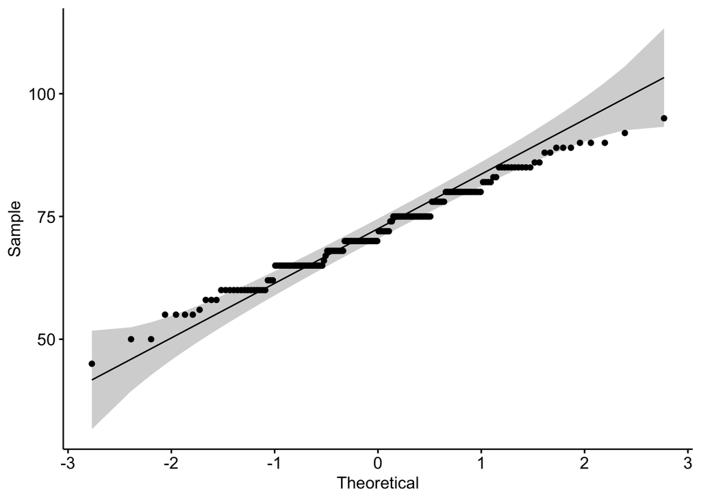

#### F-test for variance

```
##
##  F test to compare two variances
##
## data:  mohk_2012_3$SIZE and mohk_2017_3$SIZE
## F = 1.3015, num df = 82, denom df = 177, p-value = 0.1509
## alternative hypothesis: true ratio of variances is not equal to 1
## 95 percent confidence interval:
##  0.9085131 1.9131403
## sample estimates:
## ratio of variances
##           1.301535
```

RESULT:  
p-value for the variance test, (0.1509427) is larger than the significance level $\alpha$ = 0.05. There is not a significant difference between the variances of the two sets of data. We will need to use student’s t-test, which is designed for equal variances, and the assumption of normality.

### T-test

```
##
##  Two Sample t-test
##
## data:  mohk_2012_3$SIZE and mohk_2017_3$SIZE
## t = 4.0689, df = 259, p-value = 6.276e-05
## alternative hypothesis: true difference in means is not equal to 0
## 95 percent confidence interval:
##  2.710776 7.795248
## sample estimates:
## mean of x mean of y
##  77.25301  72.00000
```

RESULT:  
Mean Lobster Sizes differ significantly between the 2012 and 2017 at MOHK at significance level $\alpha$ = 0.05. (t(259) = 4.07, *p* = 6.276403510^{-5}).

## CARP

#### Visual Data

2012

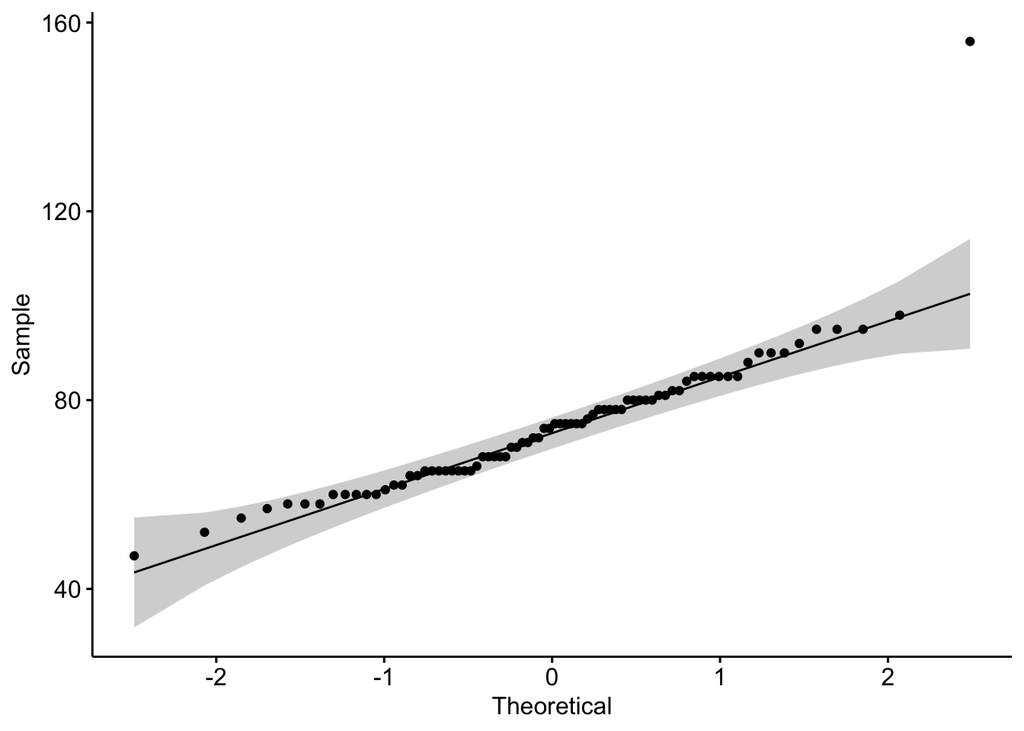

2017

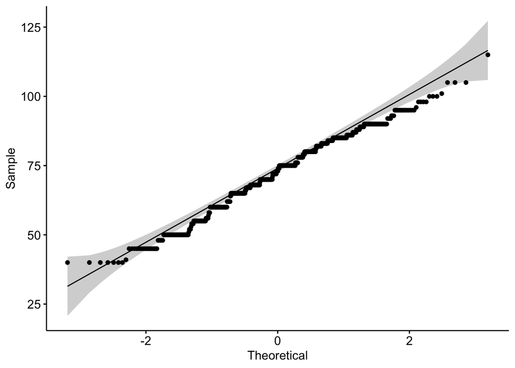

#### F-test for variance

```
##
##  F test to compare two variances
##
## data:  carp_2012_3$SIZE and carp_2017_3$SIZE
## F = 1.2244, num df = 77, denom df = 704, p-value = 0.2043
## alternative hypothesis: true ratio of variances is not equal to 1
## 95 percent confidence interval:
##  0.896208 1.750406
## sample estimates:
## ratio of variances
##           1.224405
```

RESULT:  
p-value for the variance test, (0.2042591) is larger than the significance level $\alpha$ = 0.05. There is not a significant difference between the variances of the two sets of data. We will need to use student’s t-test, which is designed for equal variances, and the assumption of normality.

#### T-test

```
##
##  Two Sample t-test
##
## data:  carp_2012_3$SIZE and carp_2017_3$SIZE
## t = 1.3361, df = 781, p-value = 0.1819
## alternative hypothesis: true difference in means is not equal to 0
## 95 percent confidence interval:
##  -0.998958  5.257332
## sample estimates:
## mean of x mean of y
##  74.35897  72.22979
```

RESULT:  
Mean Lobster Sizes do not differ significantly between the 2012 and 2017 at CARP at the 0.05 confidence level. (t(781) = 1.34, *p* = 0.1818961).